# `ggplot2` Solutions: Gapminder Data

Put Your Name Here

Wed 17 Feb 2021 (18:00:58)

# Gapminder Data

We will use a subset of the gapminder data[^1]. The variables in the dataset are as follows.

- `continent`: Continent
- `country`: Country name
- `year`: Year
- `pop`: Population
- `gdpPercap`: GDP per capita (US$, inflation-adjusted)
- `lefeexp`: Life expectancy at birth, in years
- `infmort`: Infant Mortality (rate per 1000 births)
- `fertility`: Children per woman

## Read in the data

```r
library(data.table)
library(here)

gm <- fread(here("data", "gapminder.csv"))

# Some modifications which will be useful later
gm[, continent:=as.factor(continent)]
gm[, country:=as.factor(country)]
gm[, fyear:=as.factor(year)]
gm
```

```
##       continent  country year      pop gdpPercap lifeexp infmort fertility fyear
##    1:    Europe  Albania 1960  1636054        NA   62.87   115.4      6.19  1960
##    2:    Europe  Albania 1965  1896125        NA   66.59    94.1      5.59  1965
##    3:    Europe  Albania 1970  2150602        NA   67.83    76.8      5.05  1970
##    4:    Europe  Albania 1975  2411229        NA   69.77    63.1      4.39  1975
##    5:    Europe  Albania 1980  2681245 1056.7504   71.39    64.0      3.68  1980
##   ---
## 2216:    Africa Zimbabwe 1995 11683136  510.8200   56.00    60.1      4.43  1995
## 2217:    Africa Zimbabwe 2000 12499981  535.1974   47.90    63.5      4.07  2000
## 2218:    Africa Zimbabwe 2005 12984418  351.0233   45.10    61.0      3.97  2005
## 2219:    Africa Zimbabwe 2010 13973897  288.5683   49.10    55.8      3.72  2010
## 2220:    Africa Zimbabwe 2015 15602751        NA   59.30    46.6      3.35  2015
```

```r
str(gm)
```

```
## Classes 'data.table' and 'data.frame':   2220 obs. of  9 variables:
##  $ continent: Factor w/ 5 levels "Africa","Americas",..: 4 4 4 4 4 4 4 4 4 4 ...
##  $ country  : Factor w/ 185 levels "Albania","Algeria",..: 1 1 1 1 1 1 1 1 1 1 ...
##  $ year     : int  1960 1965 1970 1975 1980 1985 1990 1995 2000 2005 ...
##  $ pop      : int  1636054 1896125 2150602 2411229 2681245 2966799 3281453 3106727 3121965 3082172 ...
##  $ gdpPercap: num  NA NA NA NA 1057 ...
##  $ lifeexp  : num  62.9 66.6 67.8 69.8 71.4 ...
##  $ infmort  : num  115.4 94.1 76.8 63.1 64 ...
##  $ fertility: num  6.19 5.59 5.05 4.39 3.68 3.23 2.97 2.72 2.38 1.92 ...
##  $ fyear    : Factor w/ 12 levels "1960","1965",..: 1 2 3 4 5 6 7 8 9 10 ...
##  - attr(*, ".internal.selfref")=<externalptr>
```

```r
# A dataset with just Portuguese data
gmPT <- gm[country == "Portugal"]
gmPT
```

```
##     continent  country year      pop gdpPercap lifeexp infmort fertility fyear
##  1:    Europe Portugal 1960  8875311  2363.976   64.23    84.6      3.16  1960
##  2:    Europe Portugal 1965  8888635  3212.569   66.17    66.4      3.18  1965
##  3:    Europe Portugal 1970  8670352  4615.613   67.14    55.4      2.99  1970
##  4:    Europe Portugal 1975  9185876  5398.299   68.90    36.0      2.71  1975
##  5:    Europe Portugal 1980  9755635  6518.493   71.71    22.8      2.29  1980
##  6:    Europe Portugal 1985  9929014  6693.814   73.22    16.5      1.78  1985
##  7:    Europe Portugal 1990  9890319  8854.322   74.20    11.5      1.54  1990
##  8:    Europe Portugal 1995 10078431  9455.050   75.50     7.4      1.48  1995
##  9:    Europe Portugal 2000 10278542 11412.078   76.80     5.5      1.47  2000
## 10:    Europe Portugal 2005 10480085 11663.632   78.40     3.7      1.41  2005
## 11:    Europe Portugal 2010 10584837 11805.935   79.90     3.1      1.33  2010
## 12:    Europe Portugal 2015 10349803        NA   80.80     3.0      1.31  2015
```

# Life Expectancy - Portugal

Let’s plot life expectancy over time for Portugal.

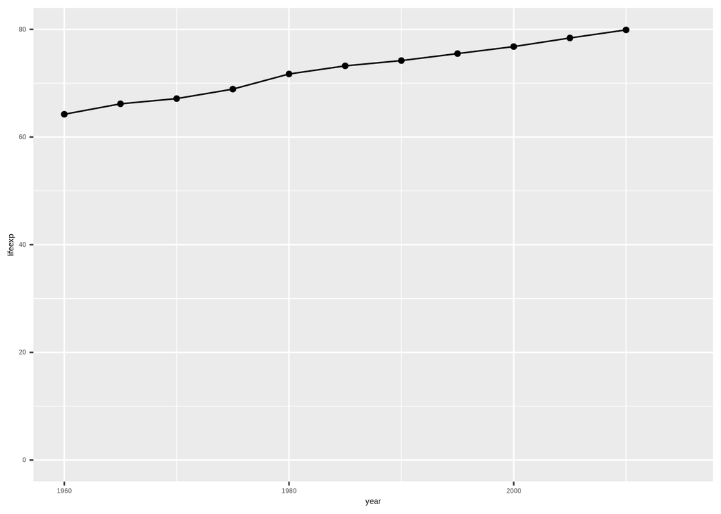

```r
library(ggplot2)
library(magrittr)

gm[country == "Portugal"] %>%
ggplot(aes(year, lifeexp)) +
  geom_point() +
  geom_line() +
  scale_y_continuous(limits=c(0, 80))
```

## Exercise 1: Portugal

### Infant Mortality - Portugal

Plot the infant mortality rate over time for Portugal. Include the following:

- Colour for the lines and plots
- Labels for the axes.
- Add “Infant Mortality - Portugal” as a title (hint: use `ggtitle()`)

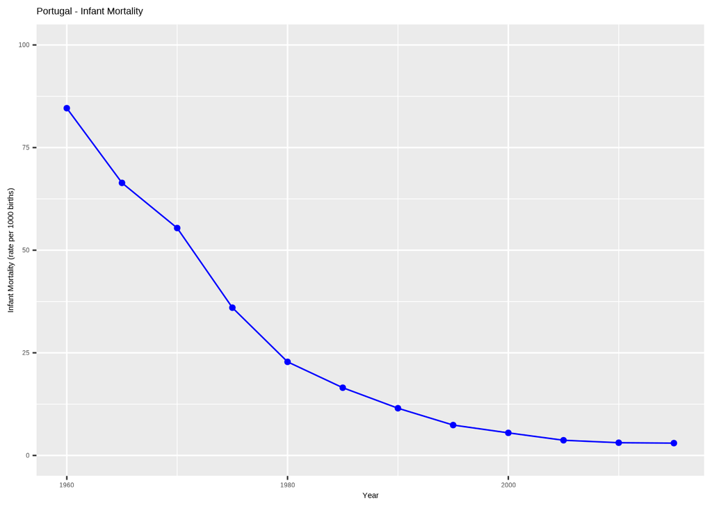

```r
gm[country == "Portugal"] %>%
ggplot(aes(year, infmort)) +
  geom_point(colour="blue") +
  geom_line(colour="blue") +
  scale_y_continuous(limits=c(0, 100)) +
  ggtitle("Portugal - Infant Mortality") +
  xlab("Year") +
  ylab("Infant Mortality (rate per 1000 births)")
```

**Interpret this plot.**

### Fertility Rate - Portugal

Plot the fertility rate over time for Portugal. Include the following:

- Colour for the lines and plots
- Labels for the axes.
- Add “Fertility Rate - Portugal” as a title (hint: use `ggtitle()`)

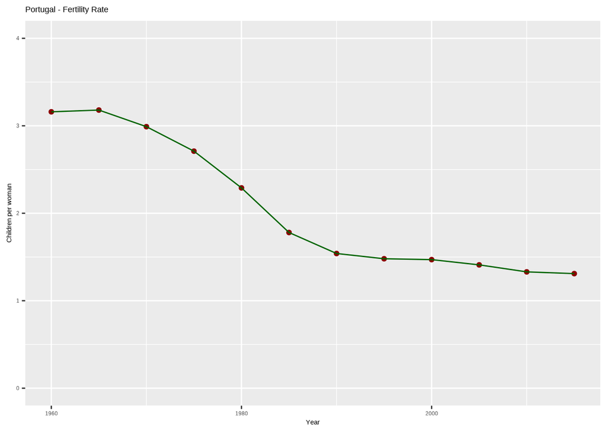

```r
gm[country == "Portugal"] %>%
ggplot(aes(year, fertility)) +
  geom_point(colour="darkred") +
  geom_line(colour="darkgreen") +
  scale_y_continuous(limits=c(0, 4)) +
  ggtitle("Portugal - Fertility Rate") +
  xlab("Year") +
  ylab("Children per woman")
```

Use the colours of the Portuguese flag,: “darkred” for points and “darkgreen” for lines. What do you notice when you switch the order of `geom_point()` and `geom_line()`? Do you strictly need to include the `geom_point()`?

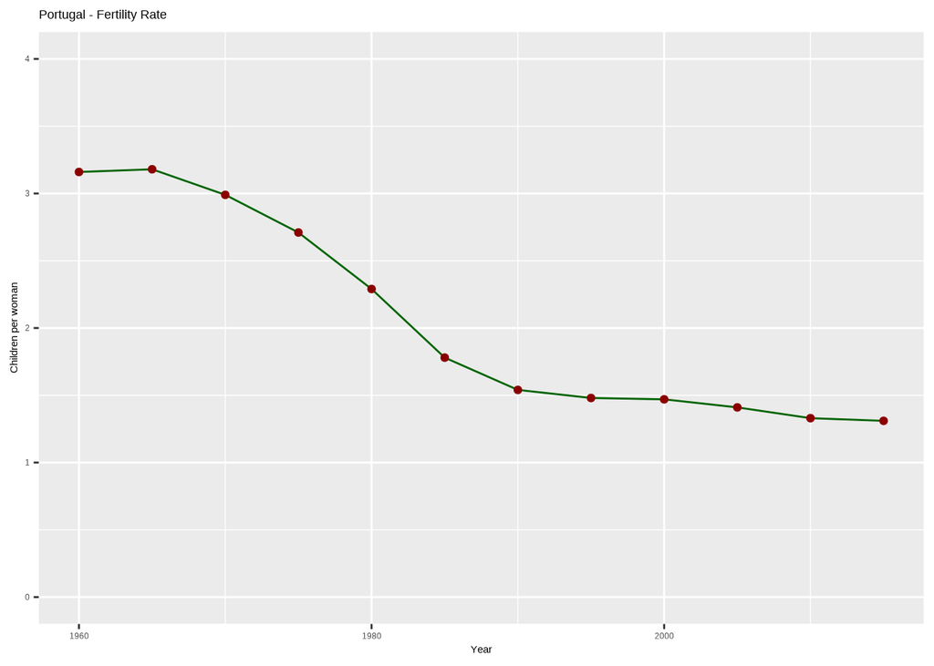

```r
gm[country == "Portugal"] %>%
ggplot(aes(year, fertility)) +
  geom_line(colour="darkgreen") +
  geom_point(colour="darkred") +
  scale_y_continuous(limits=c(0, 4)) +
  ggtitle("Portugal - Fertility Rate") +
  xlab("Year") +
  ylab("Children per woman")
```

**Interpret this plot.**

### Population & GDP

Produce the same plots as above for population and GDP per capita. How do you interpret them?

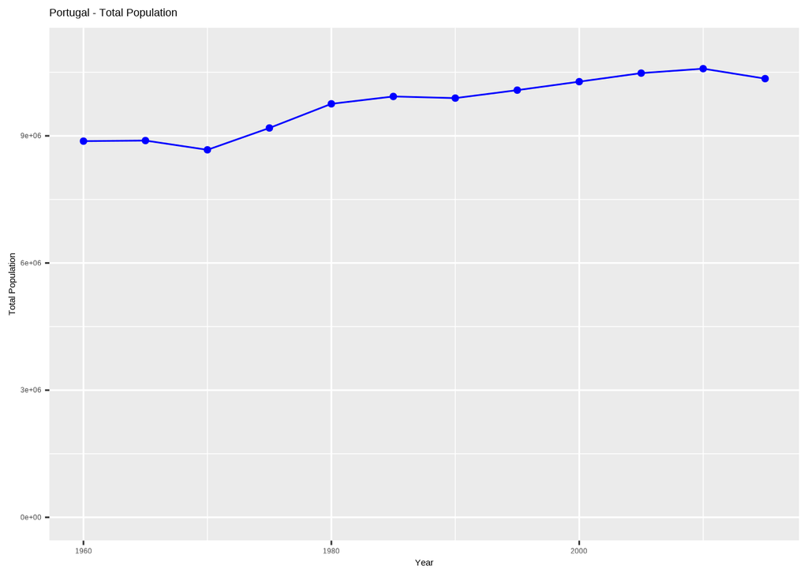

```r
gm[country == "Portugal"] %>%
ggplot(aes(year, pop)) +
  geom_point(colour="blue") +
  geom_line(colour="blue") +
  scale_y_continuous(limits=c(0, 11000000)) +
  ggtitle("Portugal - Total Population") +
  xlab("Year") +
  ylab("Total Population")
```

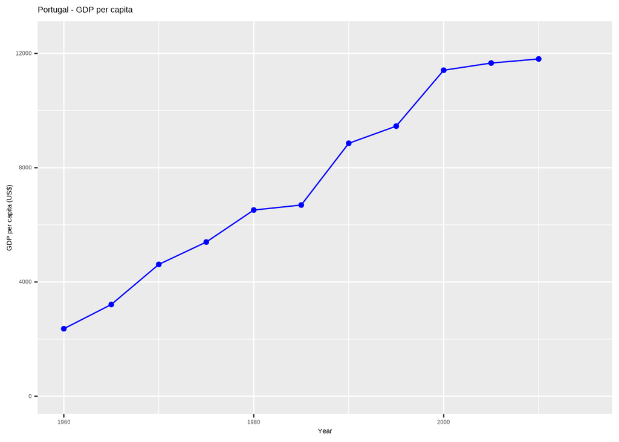

```r
gm[country == "Portugal"] %>%
ggplot(aes(year, gdpPercap)) +
  geom_point(colour="blue") +
  geom_line(colour="blue") +
  scale_y_continuous(limits=c(0, 12500)) +
  ggtitle("Portugal - GDP per capita") +
  xlab("Year") +
  ylab("GDP per capita (US$)")
```

# Life Expectancy - Europe

## Exercise 2: Europe

In this exercise we will evaluate how Portugal performs in Europe for:

- Infant Mortality
- Fertility Rate
- GDP per Capita

Produce the follow plots:

- Boxplot over time
- Line plot over time with European countries in grey and Portugal in blue.

### Infant Mortality - Portugal in Europe

The performance of Portugal in Europe for infant mortality rate (per 1000 births).

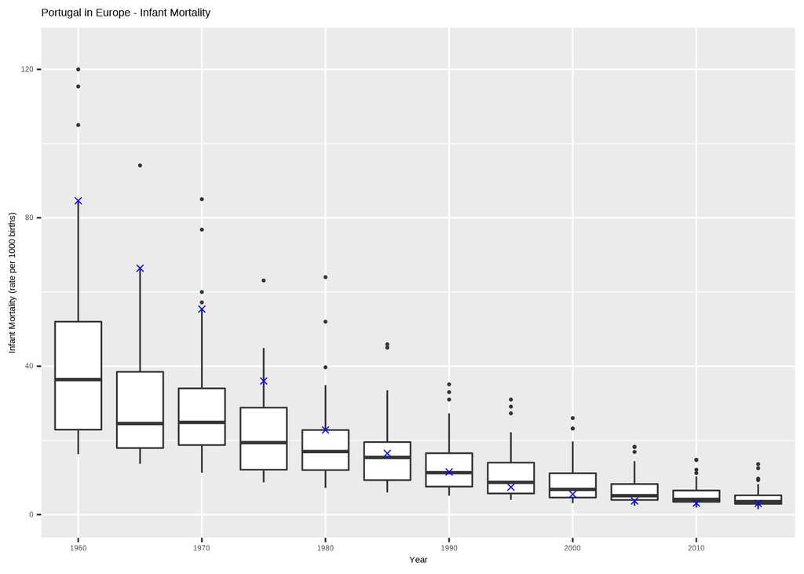

```r
gm[continent=="Europe"] %>%
  ggplot(aes(fyear, infmort)) +
  geom_boxplot(outlier.size = .5) +
  geom_point(data=gmPT, shape = 4, colour="blue") +
  scale_x_discrete(breaks=seq(1960, 2010, 10)) +
  scale_y_continuous(limits=c(0, 125)) +
  ggtitle("Portugal in Europe - Infant Mortality") +
  xlab("Year") +
  ylab("Infant Mortality (rate per 1000 births)")
```

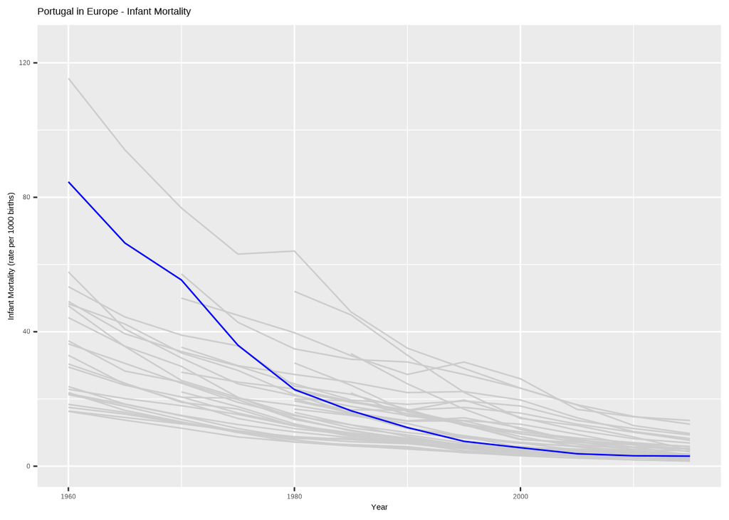

```r
gm[continent=="Europe"] %>%
  ggplot(aes(year, infmort, group=country)) +
  geom_line(colour="grey80") +
  geom_line(data=gmPT, colour="blue") +
  scale_y_continuous(limits=c(0, 125)) +
  ggtitle("Portugal in Europe - Infant Mortality") +
  xlab("Year") +
  ylab("Infant Mortality (rate per 1000 births)")
```

**Interpret this plot.** How does Portugal perform relative to other EU countries?

### Fertility Rate - Portugal in Europe

The performance of Portugal in Europe for the total fertility rate (children per woman).

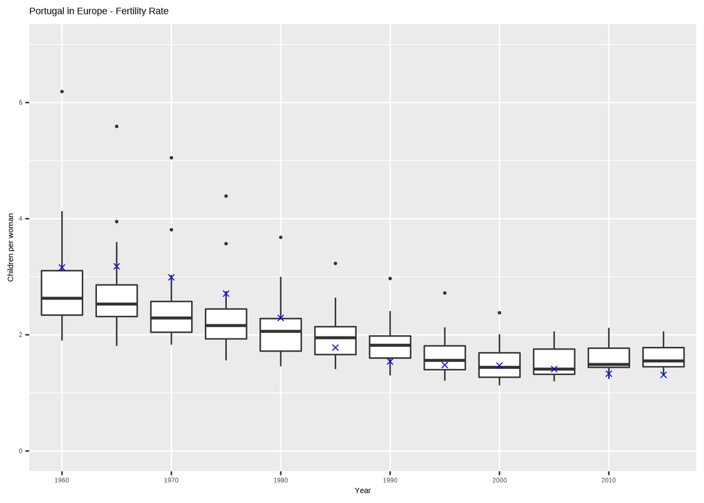

```r
gm[continent=="Europe"] %>%
  ggplot(aes(fyear, fertility)) +
  geom_boxplot(outlier.size = .5) +
  geom_point(data=gmPT, shape = 4, colour="blue") +
  scale_x_discrete(breaks=seq(1960, 2010, 10)) +
  scale_y_continuous(limits=c(0, 7)) +
  ggtitle("Portugal in Europe - Fertility Rate") +
  xlab("Year") +
  ylab("Children per woman")
```

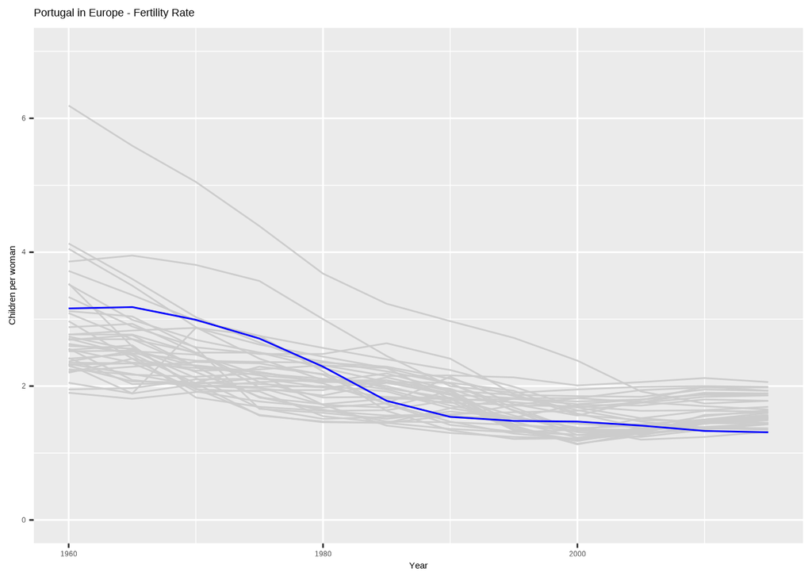

```r
gm[continent=="Europe"] %>%
  ggplot(aes(year, fertility, group=country)) +
  geom_line(colour="grey80") +
  geom_line(data=gmPT, colour="blue") +
  scale_y_continuous(limits=c(0, 7)) +
  ggtitle("Portugal in Europe - Fertility Rate") +
  xlab("Year") +
  ylab("Children per woman")
```

**Interpret this plot.** How does Portugal perform relative to other EU countries?

### GDP - Portugal in Europe

The performance of Portugal in Europe for the GDP per capita (inflation adjusted US$).

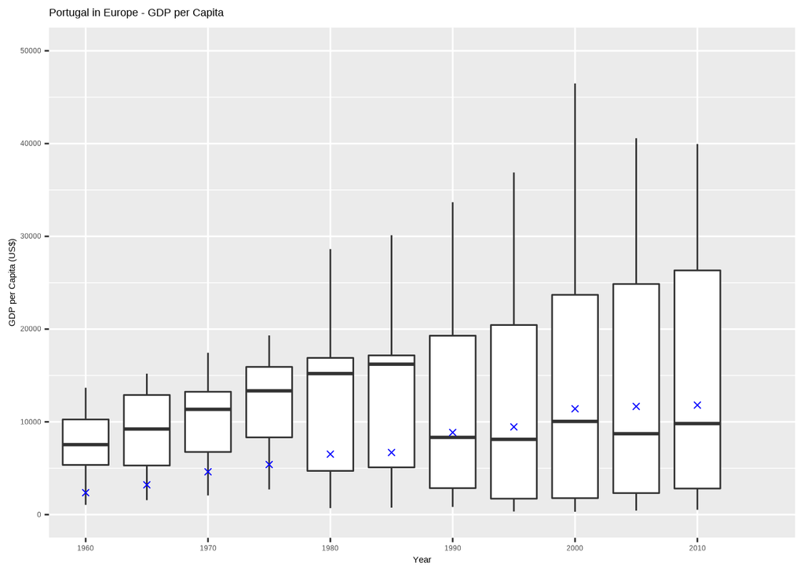

```r
gm[continent=="Europe"] %>%
  ggplot(aes(fyear, gdpPercap)) +
  geom_boxplot(outlier.size = .5) +
  geom_point(data=gmPT, shape = 4, colour="blue") +
  scale_x_discrete(breaks=seq(1960, 2010, 10)) +
  scale_y_continuous(limits=c(0, 50000)) +
  ggtitle("Portugal in Europe - GDP per Capita") +
  xlab("Year") +
  ylab("GDP per Capita (US$)")
```

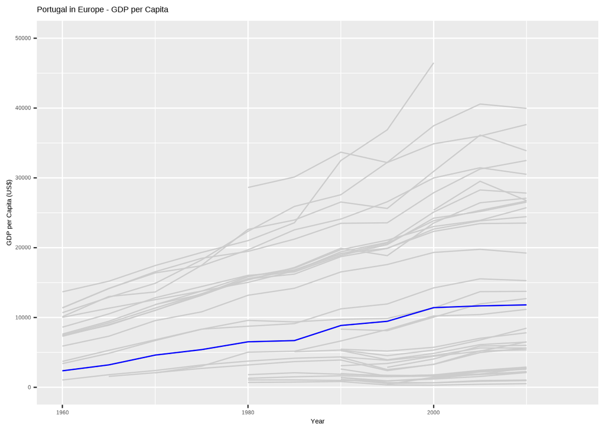

```r
gm[continent=="Europe"] %>%
  ggplot(aes(year, gdpPercap, group=country)) +
  geom_line(colour="grey80") +
  geom_line(data=gmPT, colour="blue") +
  scale_y_continuous(limits=c(0, 50000)) +
  ggtitle("Portugal in Europe - GDP per Capita") +
  xlab("Year") +
  ylab("GDP per Capita (US$)")
```

**Interpret this plot.** How does Portugal perform relative to other EU countries?